# ITMD514_01&05_Final_Project_HVRR

The second plot is a stacked bar plot depicting the distribution of Household Net Worth categories by race. It shows the proportion of each race group in different Net Worth ranges, providing insights into wealth distribution across racial groups”)

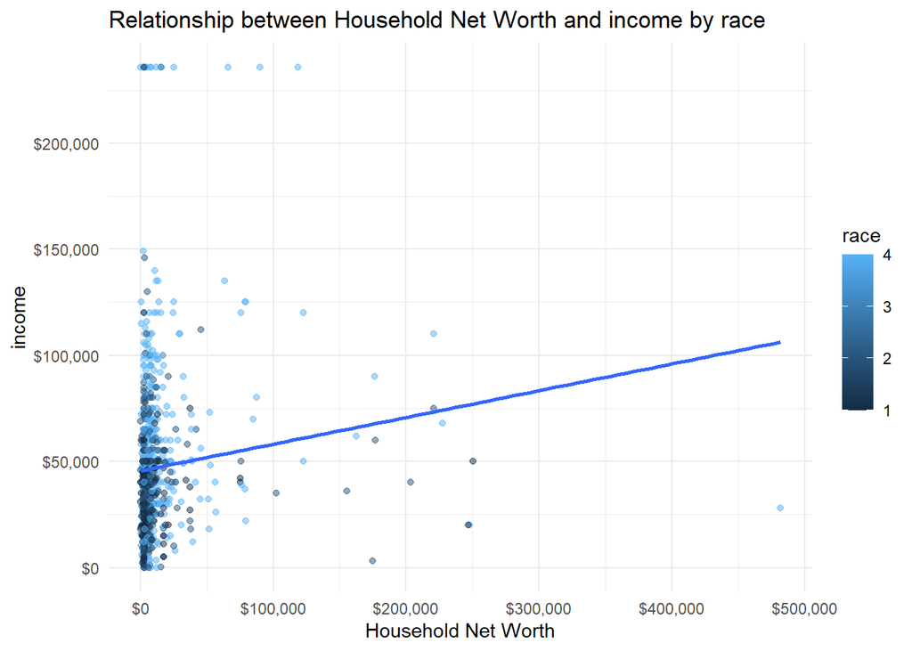

```r
#  Household Net Worth and income

# Scatter plot of household net worth vs income, colored by race
ggplot(nlsy, aes(x = Household_Net_Worth, y = income, color = race)) +
  geom_point(alpha = 0.5) +
  geom_smooth(method = "lm", se = FALSE) +
  scale_x_continuous(labels = scales::dollar_format()) +
  scale_y_continuous(labels = scales::dollar_format()) +
  labs(title = "Relationship between Household Net Worth and income by race",
       x = "Household Net Worth", y = "income") +
  theme_minimal()
```

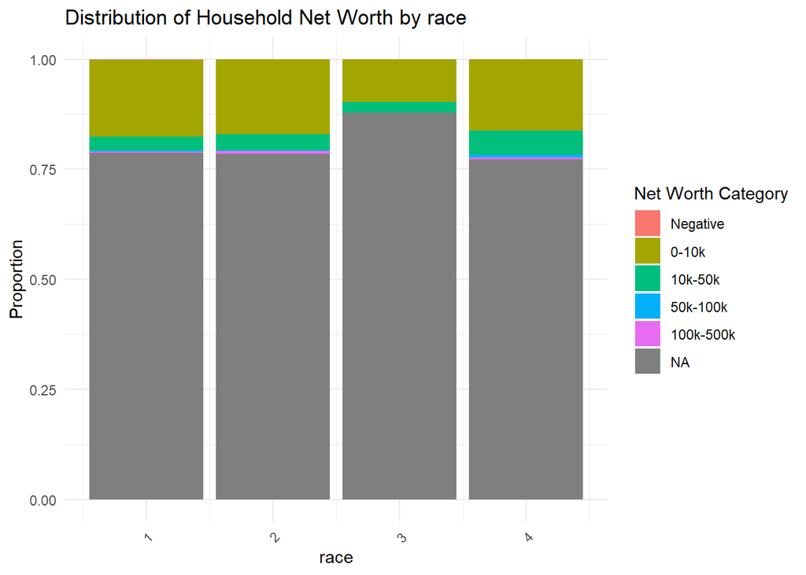

```r
# Stacked bar plot of household net worth distribution by race
nlsy %>%
  mutate(Net_Worth_Category = cut(Household_Net_Worth,
                                  breaks = c(-Inf, 0, 10000, 50000, 100000, 500000, Inf),
                                  labels = c("Negative", "0-10k", "10k-50k", "50k-100k", "100k-500k", "500k+"))) %>%
  ggplot(aes(x = race, fill = Net_Worth_Category)) +
  geom_bar(position = "fill") +
  labs(title = "Distribution of Household Net Worth by race",
       x = "race", y = "Proportion", fill = "Net Worth Category") +
  theme_minimal() +
  theme(axis.text.x = element_text(angle = 45, hjust = 1))
```

print(“The output of the multiple linear regression model provides the coefficients, standard errors, t-values, and p-values for each predictor variable (e.g., race, GPA, Total Incarcerations, Household Net Worth, Urban/Rural, and Gender) in explaining income. The summary(model) output shows which variables significantly affect income based on p-values (typically < 0.05 indicates significance). The residual plots (shown using `plot(model)`) are diagnostic tools to check for issues like non-linearity, heteroscedasticity, and outliers. These plots help assess the model’s assumptions and ensure reliable results from the regression”)

```r
# . Advanced Statistical Analysis
# 4.1 Multiple Linear Regression

# Prepare data for regression
regression_data <- nlsy %>%
  select(income, race, GPA, Total_Incarcerations, Household_Net_Worth, Urban_Rural, Gender) %>%
  na.omit()

# Run multiple linear regression
model <- lm(income ~ race + GPA + Total_Incarcerations + Household_Net_Worth + Urban_Rural + Gender,
            data = regression_data)

# print summary of the model
summary(model)
```

```
##
## Call:
## lm(formula = income ~ race + GPA + Total_Incarcerations + Household_Net_Worth +
##     Urban_Rural + Gender, data = regression_data)
##
## Residuals:
##    Min     1Q Median     3Q    Max
## -65643 -28923 -10814  13885 193996
##
## Coefficients:
##                         Estimate Std. Error t value Pr(>|t|)
## (Intercept)            6.425e+04  1.958e+04   3.282  0.00123 **
## race                   5.856e+03  3.432e+03   1.707  0.08954 .
## GPALess than 3.00 GPA -2.199e+04  1.149e+04  -1.914  0.05716 .
## Total_Incarcerations  -2.507e+04  1.245e+04  -2.014  0.04540 *
## Household_Net_Worth    2.191e-01  1.039e-01   2.108  0.03631 *
## Urban_Rural            8.399e+03  7.809e+03   1.075  0.28352
## Gender                -1.858e+04  6.906e+03  -2.691  0.00776 **
## ---
## Signif. codes:  0 '***' 0.001 '**' 0.01 '*' 0.05 '.' 0.1 ' ' 1
##
## Residual standard error: 47180 on 191 degrees of freedom
## Multiple R-squared:  0.1274, Adjusted R-squared:  0.09995
## F-statistic: 4.646 on 6 and 191 DF,  p-value: 0.0001966
```

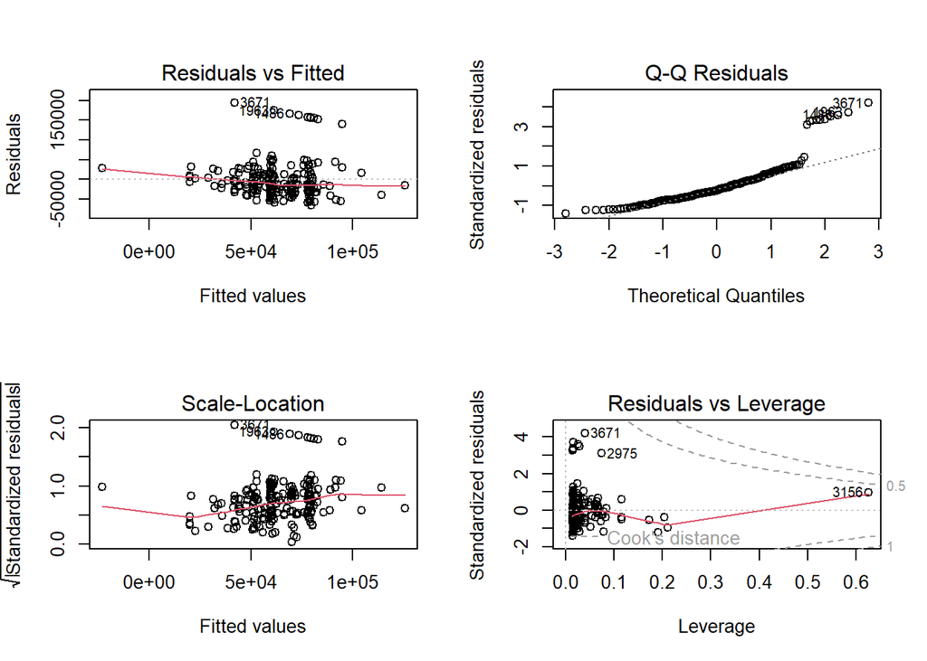

```r
# Plot residuals
par(mfrow = c(2, 2))
plot(model)
```

print(“The ANOVA output tests the hypothesis that income varies significantly across race groups. The summary(anova_result) provides the F-statistic and p-value, indicating whether there are significant differences in income between race groups. If the p-value is below 0.05, the null hypothesis is rejected, suggesting significant income differences. The Tukey’s HSD post-hoc test compares all pairwise combinations of races, showing which specific groups differ significantly. The plot(tukey_result) visualizes the confidence intervals for each pairwise comparison, helping to identify significant differences in income between specific race groups”)